# Exploring the BRFSS data

## Setup

### Load packages

```r
library(ggplot2)
library(dplyr)
library(gmodels)
```

### Load data

```r
load(file.choose())
```

## Part 1: Data

A risk factor is any attribute, characteristic or exposure of an individual that increases the likelihood of developing a disease or injury (http://www.who.int/topics/risk_factors/en/). Behavioral Risk Factors are behaviors that exert a strong influence on health such as tobacco use, alcohol consumption, physical activity and diet, sexual practices and the like (https://www.ncbi.nlm.nih.gov/books/NBK43744/).

In 1984, the Centers for Disease Control and Prevention (CDC) initiated the state-based Behavioral Risk Factor Surveillance System (BRFSS)–a cross-sectional telephone survey that state health departments conduct monthly over landline telephones and cellular telephones with a standardized questionnaire and technical and methodologic assistance from CDC. BRFSS is used to collect prevalence data among adult U.S. residents regarding their risk behaviors and preventive health practices that can affect their health status. Respondent data are forwarded to CDC to be aggregated for each state, returned with standard tabulations, and published at year’s end by each state (https://www.cdc.gov/brfss/index.html).

```r
head(brfss2013[,1:10]) #taking a look at the first 10 columns
```

```
##   X_state   fmonth   idate   imonth iday iyear            dispcode
## 1 Alabama  January 1092013  January    9  2013 Completed interview
## 2 Alabama  January 1192013  January   19  2013 Completed interview
## 3 Alabama  January 1192013  January   19  2013 Completed interview
## 4 Alabama  January 1112013  January   11  2013 Completed interview
## 5 Alabama February 2062013 February    6  2013 Completed interview
## 6 Alabama    March 3272013    March   27  2013 Completed interview
##        seqno      X_psu ctelenum
## 1 2013000580 2013000580      Yes
## 2 2013000593 2013000593      Yes
## 3 2013000600 2013000600      Yes
## 4 2013000606 2013000606      Yes
## 5 2013000608 2013000608      Yes
## 6 2013000630 2013000630      Yes
```

Each row in the data uniquely identifies a household and this data is from the survey conducted in 2013 only. From the PDF posted on the documentation page here (https://www.cdc.gov/brfss/data_documentation/index.htm), the following points may be noted :-

All in all:

- The study is observational. The data is collected in a way that does not interfere with how the data arises. We can only establish an association between 2 variables (explanatory and response) owing to the presence of confounding variables. To establish causal relationships, we must carry out an experiment.
- It’s prospective as data is collected throughout the study.
- The method of sampling is Disproportionate Stratified Sampling. Landline Telephone Numbers and Cellular Telephone Numbers are considered seperate. This has been observed to be more efficient than simple random sampling.
- The scope of inference can be extended to adults aged 18 years and above that own a telephone (landline or cellular). However if you only wish to draw inference from a part of the population, the generalization scope ALSO depends on your choice of sample. Interviews conducted on cellular telephone numbers can be generalised to single adult household, whereas interviews conducted on landline telphone numbers can be generalised to multiple adults household. If you use the whole dataset for exploratory data analysis, then you can generalize findings to the American population aged 18 years and above. The distinction can be made by the variable ‘cellfon2’. For all those obervations that have the value of ‘Yes’ for cellfon2, they don’t have values for numadult, nummen and numwomen that represent the number of adults in the household - men and women.
- Upto 15 calling attempts are made which reduces non-response bias. However since these interviews are telephonic and there is no way to medically verify the information, individuals may falsely report information about things such as their drinking/smoking habits, their weight etc. owing to the sensitive nature of the study

## Part 2: Research questions

**Research quesion 1:** How much exercise do different people get (different with respect to their Body Mass Index (BMI) categories)? The BMI is one metric for measuring overall health. It isn’t a perfect metric as women tend to have more fat than men and the BMI doesn’t take into account muscle weight. However since we don’t have access to other factors such as body fat percentage, we can analyze BMI vs exerany2 (Exercise In Past 30 Days) to establish an association between being healthy and exercising.

The variables that we will be using are height3, weight2 and exerany2

**Research quesion 2:** What effect does income have on people’s smoking habits? Do people who earn well tend to smoke more as a result of working more? This is of course assuming people tend to work more when they earn well. Or do people in the lower income brackets smoke more as a result of stress culminating from low income plus work burden?

The variables that we will be using are income2, smokday2 and sleptim1

**Research quesion 3:** What is the difference in the drinking pattern of those adults who live in a single adult household vs those who stay in a household with multiple adults? For all those people who drink - do people living in single adult households drink more than the ones who stay in multiple adults households? One may suggest this hypothesis as people who stay alone don’t have family commitments or otherwise and they may drink more than the ones who stay with their families.

The variables that we will be using are cellfon2, alcday5, avedrnk2 and maxdrnks

## Part 3: Exploratory data analysis

**Research quesion 1:** How much exercise do different people get (different with respect to their Body Mass Index (BMI) categories)?

height3 is height in inches, however some respondents have also given their height in metres. For all respondents who have given their height in metres, the number 9 is added just before the height. Similarly weight2 is weight in pounds but some respondents have also given their weight in kgs. The number 9 is added for these cases just like it’s done for height.

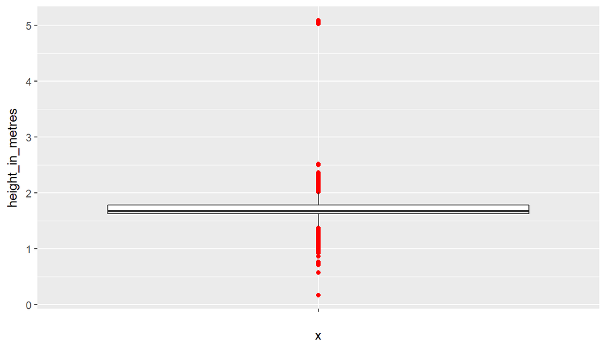

```r
#To convert height in inches to height in metres
height <- function(x){
  if (substr(toString(x), start = 1, stop = 1) != '9'){
    feet_in_inches = as.numeric(substr(toString(x), start = 1, stop = 1))*12
    inches = as.numeric(substr(toString(x), start = 2, stop = 3))
    height_in_cm = (feet_in_inches + inches)*2.54
    height_in_metres = height_in_cm/100
    return(height_in_metres)
  }
  else if (substr(toString(x), start = 1, stop = 1) == '9'){
    height_in_metres = as.numeric(substr(toString(x), start = 2, stop = 4))/100
    return(height_in_metres)
  }
}

#To convert weight in pounds to weight in kgs
weight <- function(y){
  if (substr(toString(y), start = 1, stop = 1) != '9'){
    weight_in_kg = as.numeric(toString(y))*0.453592
    return(weight_in_kg)
  }
  else if (substr(toString(y), start = 1, stop = 1) == '9'){
    weight_in_kg = as.numeric(substr(toString(y), start = 2, stop = 4))
    return(weight_in_kg)
  }
}

brfss2013$height_in_metres = suppressWarnings(sapply(brfss2013$height3, height))
brfss2013$weight_in_kg = suppressWarnings(sapply(brfss2013$weight2, weight))
ggplot(data = brfss2013, aes(x="", y=height_in_metres)) + geom_boxplot(outlier.color = 'red') #One variable boxplot
```

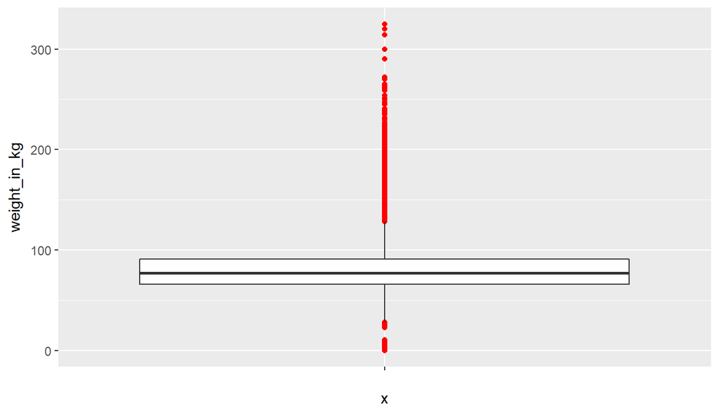

```r
ggplot(data = brfss2013, aes(x="", y=weight_in_kg)) + geom_boxplot(outlier.color = 'red')
```

As we can see, there are some outliers in both variables. We don’t expect people to be 5 metres tall. As a rule of thumb, we genrally neglect observations whose value lies beyond +/- 1.5 IQR from the whiskers of the box plot. Since in this case the IQR is narrow, we will neglect observations that lie beyond +/- 2 IQR from the whiskers of the box plot. This is just to make the analysis more meaningful, however there may be people who weigh more than the upper weight flag and/or who are taller than the upper height flag.

```r
#Removing outliers
lower_weight_flag = quantile(brfss2013$weight_in_kg, 0.25, na.rm = TRUE) - 2*IQR(brfss2013$weight_in_kg, na.rm = TRUE)
lower_weight_flag
```

```
##      25%
## 15.87572
```

```r
upper_weight_flag = quantile(brfss2013$weight_in_kg, 0.75, na.rm = TRUE) + 2*IQR(brfss2013$weight_in_kg, na.rm = TRUE)
upper_weight_flag
```

```
##      75%
## 140.6135
```

```r
lower_height_flag = quantile(brfss2013$height_in_metres, 0.25, na.rm = TRUE) - 2*IQR(brfss2013$height_in_metres, na.rm = TRUE)
lower_height_flag
```

```
##    25%
## 1.3208
```

```r
upper_height_flag = quantile(brfss2013$height_in_metres, 0.75, na.rm = TRUE) + 2*IQR(brfss2013$height_in_metres, na.rm = TRUE)
upper_height_flag
```

```
##    75%
## 2.0828
```

```r
no_outliers = brfss2013[(brfss2013$weight_in_kg >= lower_weight_flag) & (brfss2013$weight_in_kg <= upper_weight_flag) & (brfss2013$height_in_metres >= lower_height_flag) & (brfss2013$height_in_metres <= upper_height_flag), ]

print(nrow(no_outliers)) #Number of rows in the no_outliers dataframe
```

```
## [1] 484708
```

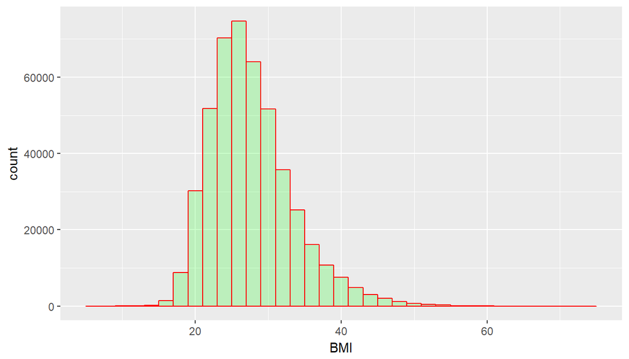

```r
no_outliers$BMI = no_outliers$weight_in_kg/(no_outliers$height_in_metres)^2 #To calculate BMI

category <- function(z){
  if (is.na(z)){
    return(NA)
  }
  else if (z < 18.5){
    return('underweight')
  }
  else if (z >= 18.5 && z < 25){
    return('healthy weight')
  }
  else if (z >= 25 && z < 30){
    return('overweight')
  }
  else if (z >= 30){
    return('obese')
  }
}
no_outliers$BMIcat = sapply(no_outliers$BMI, category) #To create BMI categories
ggplot(data=no_outliers, aes(x=BMI)) + geom_histogram(binwidth = 2, col="red", fill="green", alpha = 0.2) #Visualising the distribution of BMIs
```

Majority of the people have a BMI between 24 and 28. The distribution although normal and unimodal, seems to be right skewed.

```r
#To visualize the count of different BMI categories
bmi_exercise = na.omit(no_outliers[c('BMIcat', 'exerany2')])
print(nrow(bmi_exercise)) #Number of rows in the bmi_exercise dataframe
```

```
## [1] 432191
```

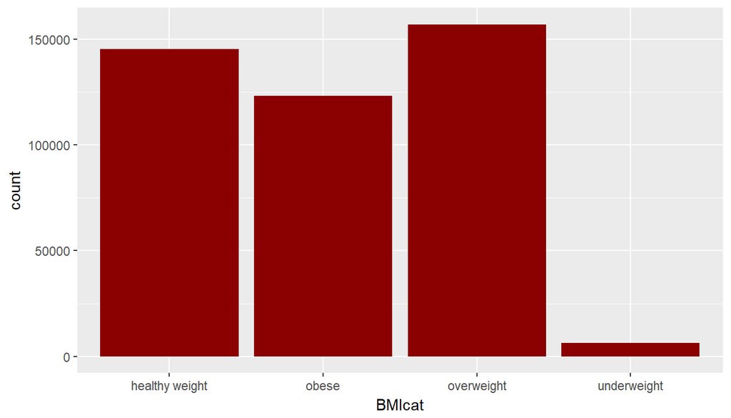

```r
ggplot(data = bmi_exercise, aes(x=BMIcat)) +  geom_bar(fill = ' dark red')
```

There are very few underweight people in the dataset. Although what we can see right away is that there are too many people who are overweight or obese with respect to their BMIs. To calculate the ratio of obese or overweight people vs healthy weight people

```r
#Ratio of obese or overweight people vs healthy weight people
nrow(bmi_exercise[bmi_exercise$BMIcat == 'obese' | bmi_exercise$BMIcat == 'overweight',])/nrow(bmi_exercise[bmi_exercise$BMIcat == 'healthy weight',])
```

```
## [1] 1.927014
```

exerany2 is a binary variable - Yes and No. And when plotted with the different BMI categories, this is what we observe

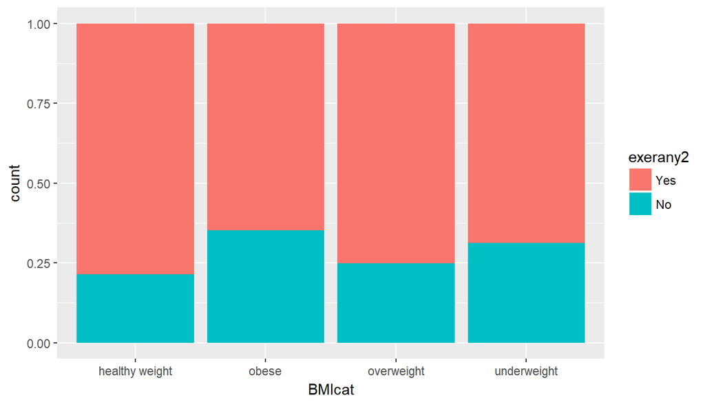

```r
#Normalised Bar Plot
ggplot(data = bmi_exercise, aes(x=BMIcat)) +  geom_bar(aes(fill=exerany2), position = 'fill')
```

```r
#To visualize the distribution of the different BMI categories vs the exerany2 variable along with row and column proportions, we can use the CrossTable function from the gmodels package
CrossTable(bmi_exercise$BMIcat, bmi_exercise$exerany2)
```

```
##
##
##    Cell Contents
## |-------------------------|
## |                       N |
## | Chi-square contribution |
## |           N / Row Total |
## |           N / Col Total |
## |         N / Table Total |
## |-------------------------|
##
##
## Total Observations in Table:  432191
##
##
##                     | bmi_exercise$exerany2
## bmi_exercise$BMIcat |       Yes |        No | Row Total |
## --------------------|-----------|-----------|-----------|
##      healthy weight |    114251 |     31202 |    145453 |
##                     |   564.428 |  1543.069 |           |
##                     |     0.785 |     0.215 |     0.337 |
##                     |     0.361 |     0.270 |           |
##                     |     0.264 |     0.072 |           |
## --------------------|-----------|-----------|-----------|
##               obese |     79803 |     43392 |    123195 |
##                     |  1198.645 |  3276.931 |           |
##                     |     0.648 |     0.352 |     0.285 |
##                     |     0.252 |     0.375 |           |
##                     |     0.185 |     0.100 |           |
## --------------------|-----------|-----------|-----------|
##          overweight |    117960 |     39135 |    157095 |
##                     |    75.047 |   205.169 |           |
##                     |     0.751 |     0.249 |     0.363 |
##                     |     0.373 |     0.338 |           |
##                     |     0.273 |     0.091 |           |
## --------------------|-----------|-----------|-----------|
##         underweight |      4428 |      2020 |      6448 |
##                     |    18.197 |    49.748 |           |
##                     |     0.687 |     0.313 |     0.015 |
##                     |     0.014 |     0.017 |           |
##                     |     0.010 |     0.005 |           |
## --------------------|-----------|-----------|-----------|
##        Column Total |    316442 |    115749 |    432191 |
##                     |     0.732 |     0.268 |           |
## --------------------|-----------|-----------|-----------|
##
##
```

**Research quesion 2:** What effect does income have on people’s smoking habits?

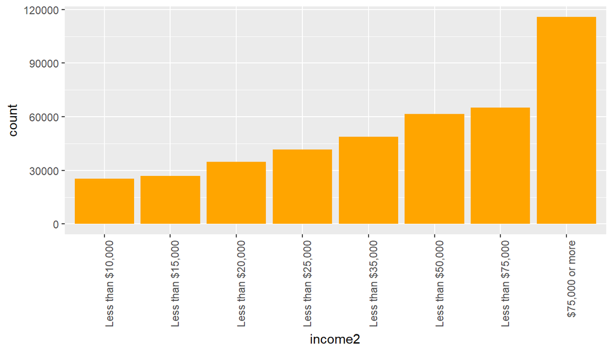

```r
#To visualize the count of different income brackets
ggplot(data = na.omit(brfss2013[c('income2')]), aes(x = income2)) +  geom_bar(fill = 'orange') + theme(axis.text.x = element_text(angle = 90, hjust = 1))
```

income2 is a categorical variable with 8 levels. The number of people earning a salary above 75000 dollars is quite high. As a proportion of those people who reported their salaries (that is, by ignoring all the NAs):

```r
nrow(brfss2013[brfss2013$income2 == '$75,000 or more',])/nrow(na.omit(brfss2013[c('income2')]))
```

```
## [1] 0.4456487
```

smokday2 is a categorical variable with 3 levels - Every day, Some days and Not at all. It represents the frequency of smoking

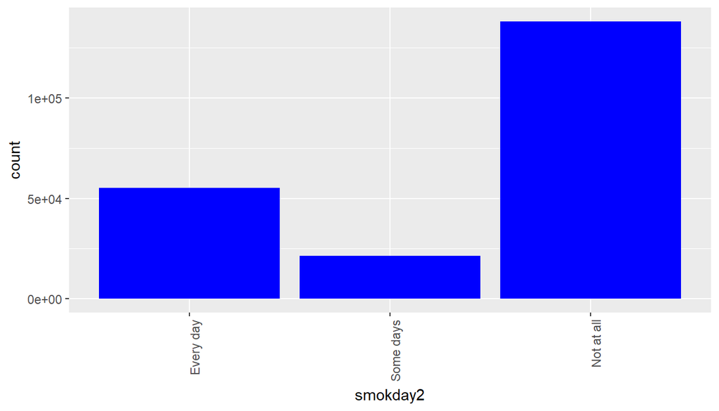

```r
ggplot(data = na.omit(brfss2013[c('smokday2')]), aes(x = smokday2)) +  geom_bar(fill = 'blue') + theme(axis.text.x = element_text(angle = 90, hjust = 1))
```

Now, to visualize the proportion of smokers with respect to each income bracket

```r
income_smoking = na.omit(brfss2013[c('income2','smokday2')]) #Omitting the null values
print(nrow(income_smoking)) #Number of rows in the income_smoking dataframe
```

```
## [1] 187809
```

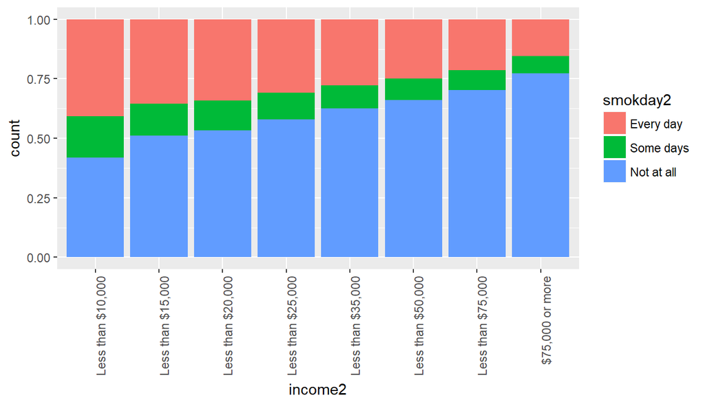

```r
ggplot(data = income_smoking, aes(x=income2)) + geom_bar(aes(fill=smokday2), position = 'fill') +  theme(axis.text.x = element_text(angle = 90, hjust = 1))
```

```r
#A numerical summary of the above plot
prop.table(table(income_smoking$income2, income_smoking$smokday2), 1)
```

```
##
##                      Every day  Some days Not at all
##   Less than $10,000 0.40793529 0.17303544 0.41902928
##   Less than $15,000 0.35416667 0.13426700 0.51156633
##   Less than $20,000 0.34120600 0.12447943 0.53431456
##   Less than $25,000 0.30869039 0.11086904 0.58044057
##   Less than $35,000 0.27786794 0.09584010 0.62629196
##   Less than $50,000 0.24874610 0.08957946 0.66167444
##   Less than $75,000 0.21365607 0.08356437 0.70277955
##   $75,000 or more   0.15354927 0.07347161 0.77297912
```

There definitely seems to be a correlation between smoking and income. One can observe that people who earn less tend to smoke more, that is, on a daily basis. 15% of people who earn 75000 dollars or more end up smoking everyday as compared to the 40% for people who earn less than 10000 dollars a year. However due to the observational nature of the study, we can only establish associations. We can however generalize this finding to the American population aged 18 years or older. One confounding variable could be sleep. We will use the variable sleptim1 which represents the average time slept everday.

```r
#Income with respect to average time slept everyday
brfss2013 %>% filter(!is.na(income2)) %>% group_by(income2) %>% summarise(mean_sh = mean(sleptim1, na.rm = TRUE)) %>% arrange(desc(mean_sh))
```

```
## # A tibble: 8 x 2
##   income2           mean_sh
##   <fct>               <dbl>
## 1 Less than $35,000    7.07
## 2 Less than $50,000    7.07
## 3 Less than $75,000    7.05
## 4 $75,000 or more      7.05
## 5 Less than $25,000    7.04
## 6 Less than $20,000    7.03
## 7 Less than $15,000    6.95
## 8 Less than $10,000    6.86
```

```r
#Average time slept by different types of smokers
brfss2013 %>% filter(!is.na(smokday2)) %>% group_by(smokday2) %>% summarise(mean_sh = mean(sleptim1, na.rm = TRUE)) %>% arrange(desc(mean_sh))
```

```
## # A tibble: 3 x 2
##   smokday2   mean_sh
##   <fct>        <dbl>
## 1 Not at all    7.12
## 2 Some days     6.88
## 3 Every day     6.75
```

Although this seems trivial, as is evident, people who smoke every day seem to sleep lesser than others and they also happen to belong to the lower income brackets. Thus making a conclusion based solely on the variables smokday2 and income2 is not correct. A thorough inpection would reveal more such confounding variables. A point to be noted is that out of all the people who reported their salaries, almost 45% earn more thean 75000 dollars.

**Research quesion 3:** What is the difference in the drinking pattern of those adults who live in a single adult household vs those who stay in a household with multiple adults?

The cellfon2 variable is concerned with all those people who were interviewed on their cellphone number.

```r
summary(brfss2013$cellfon2)
```

```
##    Yes     No   NA's
## 131628      3 360144
```

```r
#The NAs correspond to all those people who don't fall in the single adult household category. The following 2 summaries prove the point
summary(brfss2013$numadult[is.na(brfss2013$cellfon2)]) #NAs with respect to number of adults
```

```
##      1      2      3      4      5      6      7      8      9     10
## 130467 184624  32180   9985   2161    529     98     38     19      7
##     11     12     14     15     16     17     18     32     45   NA's
##      1      5      1      0      2      2      1      1      1     22
```

```r
summary(brfss2013$numadult[!is.na(brfss2013$cellfon2)]) #Non-NAs with respect to number of adults
```

```
##      1      2      3      4      5      6      7      8      9     10
##      0      2      0      0      0      0      0      0      0      0
##     11     12     14     15     16     17     18     32     45   NA's
##      0      0      0      0      0      0      0      0      0 131629
```

```r
#Calls made on cellphone are weighted as single adult households
#Since the NAs correspond to a household with multiple adults
brfss2013$cellfon2[is.na(brfss2013$cellfon2)] = 'No'
```

alcday5: alcday5: Days In Past 30/ days per week had alcoholic beverage

avedrnk2: During the past 30 days, on the days when you drank, about how many drinks did you drink on average?

maxdrnks: Most drinks on single occasion past 30 days

Now the people living in a multiple adults household may be unrelated to the other adults, however only 44 people out of the 360,079 who have a non-NA value for pvtresd1 (Do you live in a private residence?) have identified their residence as not being private. The definition of a private residence as per the variables pvtresd1 and pvtresd2 in the codebook is

“By private residence, we mean someplace like a house or apartment, that is, not in a dormitory or other type of group living situation”

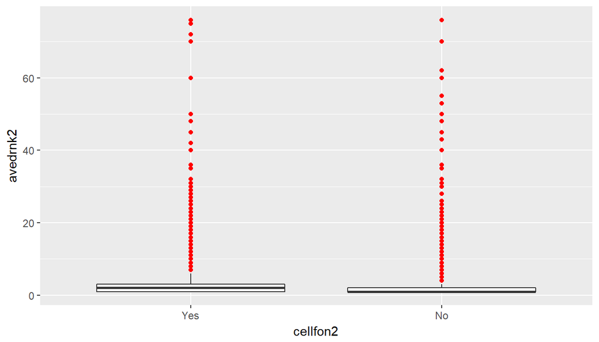

```r
#To standardize the alcday5 variable to days per month format
alc_week_month_conversion <- function(a){
  if (substr(toString(a), start = 1, stop = 1) == '1'){
    days_in_month = as.numeric(substr(toString(a), start = 2, stop = 3))*4
    return(days_in_month)
  }
  else if (substr(toString(a), start = 1, stop = 1) == '2'){
    days_in_month = as.numeric(substr(toString(a), start = 2, stop = 3))
    return(days_in_month)
  }
}
brfss2013$alc_month = suppressWarnings(sapply(brfss2013$alcday5, alc_week_month_conversion))

#Before, we even dive into the analysis, we must check for the presence of outliers
ggplot(data = brfss2013, aes(x = cellfon2, y = avedrnk2)) + geom_boxplot(outlier.color = 'red')
```

As is evident, there are too many outliers present. We must remove them to derive any kind of insight from our exploratory analysis. However there is a possibility that the observations that we consider outliers are actually accurate. Also since we’re only considering people who drink, we must remove all the NAs from the three variables and observations that have a value of 0 for alcday5 (people who haven’t drank in the past 30 days). Caution must be exercised while making any kind of inference from the analysis since the people themselves report these numbers to an interviewer. There is no definitive way of checking whether these numbers are accurate. Moreover, people may not be comfortable sharing details regarding their drinking behavior for the fear of being judged.

```r
#Removing NAs and outliers
drink_df = brfss2013[!is.na(brfss2013$alcday5) & (brfss2013$alcday5 != 0) & !is.na(brfss2013$avedrnk2) & !is.na(brfss2013$maxdrnks), ][c('alcday5','avedrnk2','maxdrnks','cellfon2')]

drink_df$alc_month = unlist(suppressWarnings(sapply(drink_df$alcday5, alc_week_month_conversion)))

#The lower flags have a lower bound of 1 as we have only included people who have drank in the past #30 days
lower_alc_month_flag = max(quantile(drink_df$alc_month, 0.25, na.rm = TRUE) - 2*IQR(drink_df$alc_month, na.rm = TRUE), 1)
lower_alc_month_flag
```

```
## [1] 1
```

```r
upper_alc_month_flag = quantile(drink_df$alc_month, 0.75, na.rm = TRUE) + 2*IQR(drink_df$alc_month, na.rm = TRUE)
upper_alc_month_flag
```

```
## 75%
##  32
```

```r
lower_avedrnk2_flag = max(quantile(drink_df$avedrnk2, 0.25) - 2*IQR(drink_df$avedrnk2), 1)
lower_avedrnk2_flag
```

```
## [1] 1
```

```r
upper_avedrnk2_flag = quantile(drink_df$avedrnk2, 0.75) + 2*IQR(drink_df$avedrnk2)
upper_avedrnk2_flag
```

```
## 75%
##   4
```

```r
lower_maxdrnks_flag = max(quantile(drink_df$maxdrnks, 0.25) - 2*IQR(drink_df$maxdrnks), 1)
lower_maxdrnks_flag
```

```
## [1] 1
```

```r
upper_maxdrnks_flag = quantile(drink_df$maxdrnks, 0.75) + 2*IQR(drink_df$maxdrnks)
upper_maxdrnks_flag
```

```
## 75%
##  10
```

```r
no_outliers_drink_df = drink_df[(drink_df$alc_month >= lower_alc_month_flag) & (drink_df$alc_month <= upper_alc_month_flag) & (drink_df$avedrnk2 >= lower_avedrnk2_flag) & (drink_df$avedrnk2 <= upper_avedrnk2_flag) & (drink_df$maxdrnks >= lower_maxdrnks_flag) & (drink_df$maxdrnks <= upper_maxdrnks_flag), ]

no_outliers_drink_df = na.omit(no_outliers_drink_df)
print(nrow(no_outliers_drink_df)) #Number of rows in the no_outliers_drink_df dataframe
```

```
## [1] 205437
```

```r
#Calculating summary statistics to determine drinking behavior of single adult household people vs
#multiple adults household people
#Median number of times alcohol was consumed in the last 30 days vs cellfon2
no_outliers_drink_df %>% group_by(cellfon2) %>% summarise(alc_times_month = median(alc_month)) %>% arrange(desc(alc_times_month))
```

```
## # A tibble: 2 x 2
##   cellfon2 alc_times_month
##   <fct>              <dbl>
## 1 No                     5
## 2 Yes                    4
```

```r
#Median number of drinks consumed on the average while having alcohol in the last 30 days vs cellfon2
no_outliers_drink_df %>% group_by(cellfon2) %>% summarise(median_drinks = median(avedrnk2)) %>% arrange(desc(median_drinks))
```

```
## # A tibble: 2 x 2
##   cellfon2 median_drinks
##   <fct>            <dbl>
## 1 Yes                  2
## 2 No                   1
```

```r
#Median number of max drinks consumed while having alcohol in the last 30 days vs cellfon2
no_outliers_drink_df %>% group_by(cellfon2) %>% summarise(median_max_drinks = median(maxdrnks)) %>% arrange(desc(median_max_drinks))
```

```
## # A tibble: 2 x 2
##   cellfon2 median_max_drinks
##   <fct>                <dbl>
## 1 Yes                      3
## 2 No                       2
```

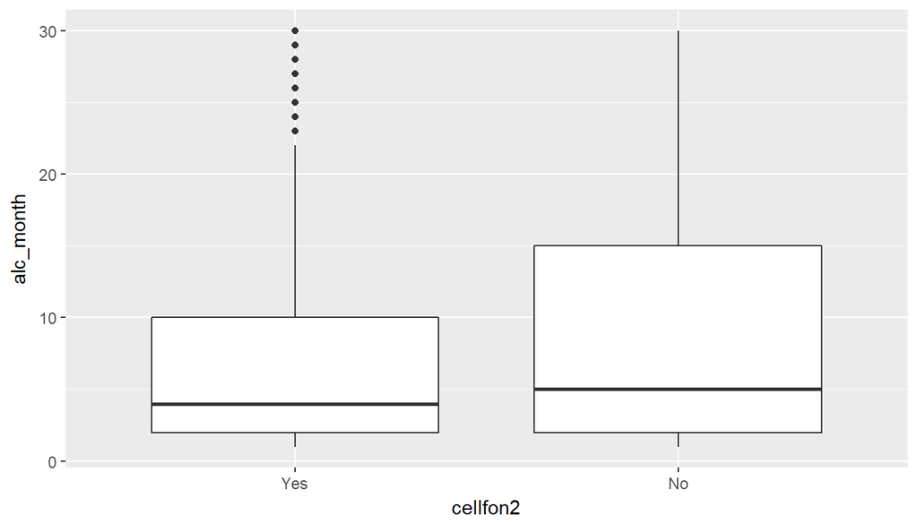

```r
#Plotting the above observations
ggplot(data = no_outliers_drink_df, aes(x = cellfon2, y = alc_month)) + geom_boxplot()
```

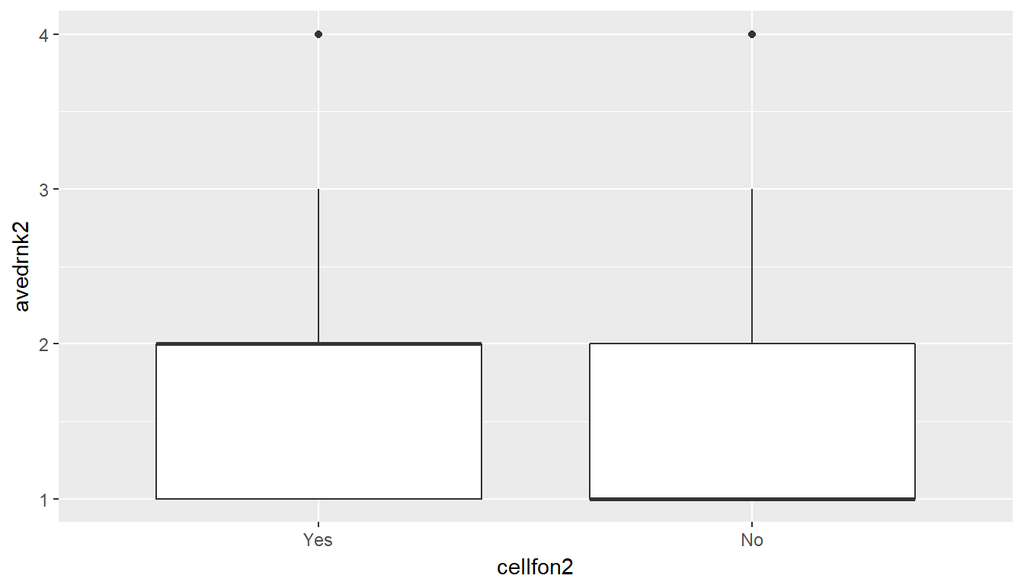

```r
ggplot(data = no_outliers_drink_df, aes(x = cellfon2, y = avedrnk2)) + geom_boxplot()
```

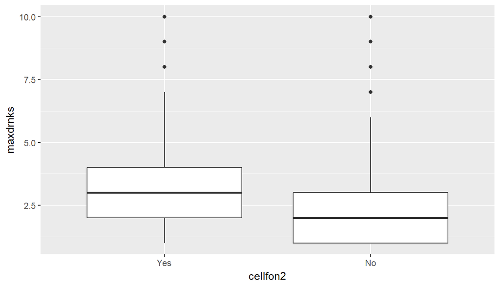

```r
ggplot(data = no_outliers_drink_df, aes(x = cellfon2, y = maxdrnks)) + geom_boxplot()
```

And there we have it - while the number of single adult household people who drink, seem to drink more than the people living in multiple adults household, the difference is not much. People living in multiple adults houshold, seem to go out drinking more than the ones living in a single adult houshold. Even if the difference was significant, we could only establish an association and generalize it to part of the American population that drinks. Sometimes we may want our beliefs to be proved right while doing exploratory data analysis, however we must realize that data is the only truth.